# Week4_tasks

# R 語言與資料科學導論作業 (W4)

生技系 b05b02048 楊崴光

## A. Complete compute_area(…) (70%)

### 撰寫compute_area函數

請完成課堂上的compute_area(…)，它必須能夠：

- 計算二種形狀的面積和周長：
  - 圓形（以半徑長當參數）
  - 正方形（以邊長當參數）

函數的型態(signature)：

- 輸入為兩個參數：
  - x: 邊長或半徑
  - shape_str: “circle” 或是 “square”
- 函數回傳：
  - 一個vector。該vector有兩個元素。第一個是面積，第二個是周長。請記得給它恰當的名稱。

```r
# your function definition goes here
area <- NULL
circum <- NULL
compute_area <- function(x,type){
  if (type == "circle") {
    area = pi * x^2
    circum = 2 * pi * x
    value <- c("circle_area" = area, "circle_circum" = circum)
  }
  else if (type == "square"){
    area = x^2
    circum = 4 * x
    value <- c("square_area" = area, "square_circum" = circum)
  }
  else print("Can't Compute")
  return(value)
}
```

假設你的函數名稱也是compute_area，且參數順序是邊長（半徑）和形狀，那以下的結果應該要是一樣的。

```r
# call your function (circle),
# e.g. circ_ret <- compute_area(6.5, "circle")
compute_area(6.5, "circle")
```

```
##   circle_area circle_circum
##      132.7323       40.8407
```

```r
circ_ret <- compute_area(6.5, "circle")
##   circle_area circle_circum
##      132.7323       40.8407
```

```r
# call your function (square),
# e.g. sqr_ret <- compute_area(5.2, "square")
compute_area(5.2, "square")
```

```
##   square_area square_circum
##         27.04         20.80
```

```r
sqr_ret <- compute_area(5.2, "square")
##   square_area square_circum
##         27.04         20.80
```

#### 評分標準：

- 定義compute_area函數(10%)
- compute_area函數可接受兩個參數(10%)
- 當形狀參數為“circle”時，可正確計算其面積(10%)和邊長(10%)。
- 當形狀參數為“square”時，可正確計算其面積(10%)和邊長(10%)。
- 回傳的vector有恰當名稱，標明其值為面積或邊長(10%)。

## B. Plot the future (30%)

### 繪圖函數

R內建很豐富的繪圖指令，例如繪製散佈圖、折線圖的plot 和直方圖的hist。請用說明文件幫助你找到正確的方式畫出散佈圖、折線圖和直方圖。

繪圖用的資料可以用以下code chunk直接產生。請注意，由於是資料是隨機產生的， 每次執行的資料都會是不同的。

您需要用以下的plot_data完成3張圖：

1. x 和 y 的散佈圖(10%)
2. x 和 z 的折線圖(10%)
3. y 的直方圖(10%)

您只需要繪製出圖本身即可。但當然歡迎幫它加上標題、顏色、軸標題等等。

```r
plot_data = data.frame(
    x <- 1:100,
    y <- 50 + 10 * rnorm(length(x), 0, 1),
    z <- x * 0.8 + rnorm(length(x), 0, 4)
)
```

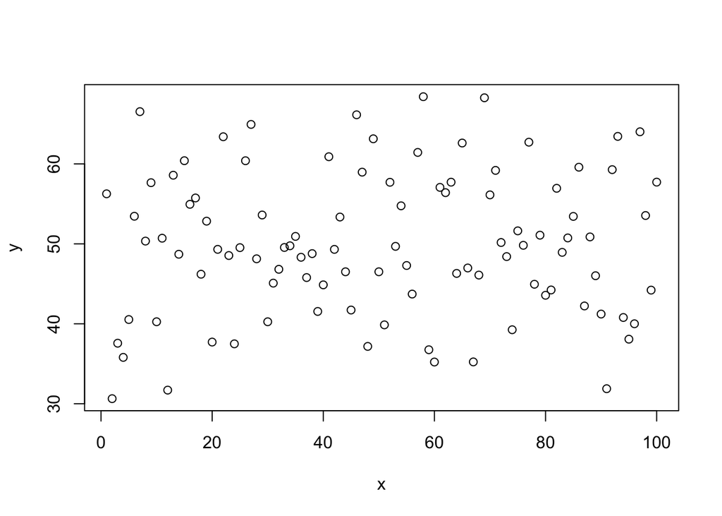

```r
# scatter plot
# your code goes here
plot(x,y)
```

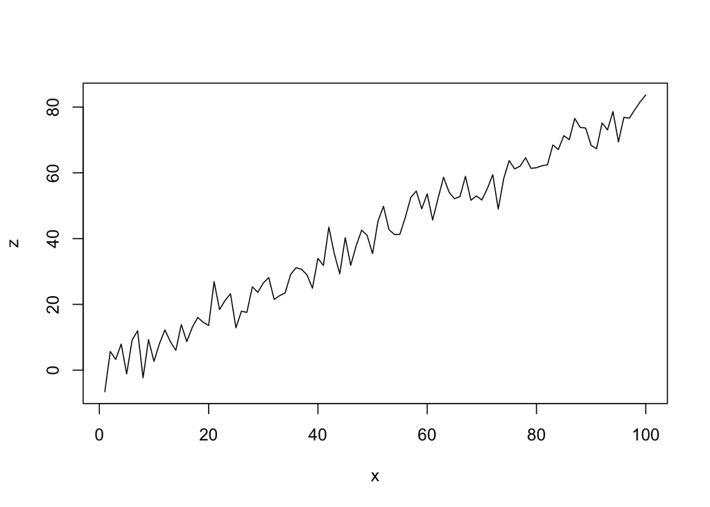

```r
# line chart
# your code goes here
plot(x, z, type = "l")
```

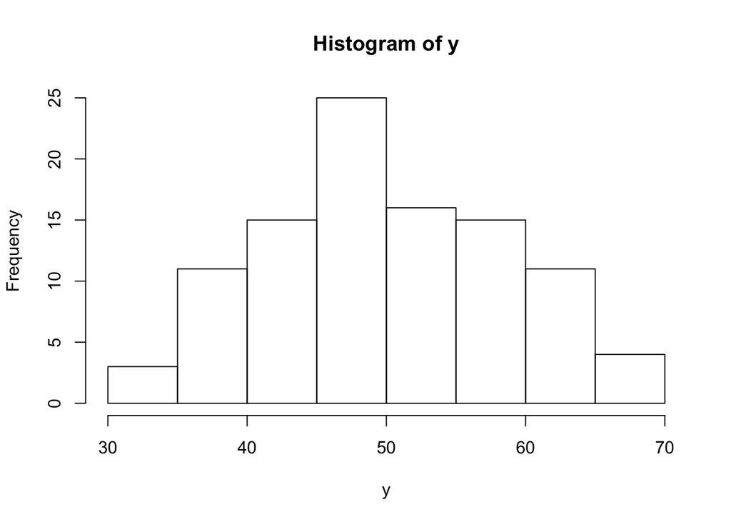

```r
# histogram
# your code goes here
hist(y)
```

## 進階選答題

### Problem A (10%)

這一題我們會用到R的內建資料集，CO2，你可以用`help(CO2)`查詢該資料內的變項和說明。 我們現在想要整理這筆資料，計算Treatment和Type兩變項下各四個情境的uptake平均數。 您可以先用head, plot, unique, table等函數看看資料內容，然後用課堂上講到的for迴圈、mean函數來整理資料。 或者，您也可以不用for迴圈，用R的內建指令或其他套件來完成這個分析。

您分析完成的結果，可能會類似這樣：

```
   Treatment        Type   uptake
1 nonchilled      Quebec  <value>
2    chilled      Quebec  <value>
3 nonchilled Mississippi  <value>
4    chilled Mississippi  <value>
```

#### 評分標準：

- 將資料整理成如上述形式。

```r
# your code goes here
Set_A <- NULL
Set_B <- NULL
Set_C <- NULL
Set_D <- NULL
N_A = 1
N_B = 1
N_C = 1
N_D = 1
for(i in 1:length(CO2[[1]])){
  if(CO2$Treatment[i] == "nonchilled" && CO2$Type[i] == "Quebec"){
    Set_A[N_A] <- CO2$uptake[i]
    N_A = N_A + 1
  }
  if(CO2$Treatment[i] == "chilled" && CO2$Type[i] == "Quebec"){
    Set_B[N_B] <- CO2$uptake[i]
    N_B = N_B + 1
  }
  if(CO2$Treatment[i] == "nonchilled" && CO2$Type[i] == "Mississippi"){
    Set_C[N_C] <- CO2$uptake[i]
    N_C = N_C + 1
  }
  if(CO2$Treatment[i] == "chilled" && CO2$Type[i] == "Mississippi"){
    Set_D[N_D] <- CO2$uptake[i]
    N_D = N_D + 1
  }
}

OutPut_A <- list(ID = 1, Treatment = "nonchilled", Type = "Quebec", uptake = mean(Set_A))
OutPut_B <- list(ID = 2, Treatment = "chilled", Type = "Quebec", uptake = mean(Set_B))
OutPut_C <- list(ID = 3, Treatment = "nonchilled", Type = "Mississippi", uptake = mean(Set_C))
OutPut_D <- list(ID = 4, Treatment = "chilled", Type = "Mississippi", uptake = mean(Set_D))
OutPut <- rbind(OutPut_A,OutPut_B,OutPut_C,OutPut_D)
OutPut
```

```
##          ID Treatment    Type          uptake
## OutPut_A 1  "nonchilled" "Quebec"      35.33333
## OutPut_B 2  "chilled"    "Quebec"      31.75238
## OutPut_C 3  "nonchilled" "Mississippi" 25.95238
## OutPut_D 4  "chilled"    "Mississippi" 15.81429
```

### Problem B (10%)

以下有一個資料產生函數`rn100()`，每呼叫一次它都會產生出100個數值。 請重複呼叫他20次，並把這20次的結果分別以不同顏色，繪製成折線圖，並呈現在同一張圖上。

#### 評分標準：

- 將20條線畫在同一張圖中(5%)。
- 每條線有不同的顏色(5%)。

```r
rn100 <- function() cumsum(rnorm(100, 0, 1))
```

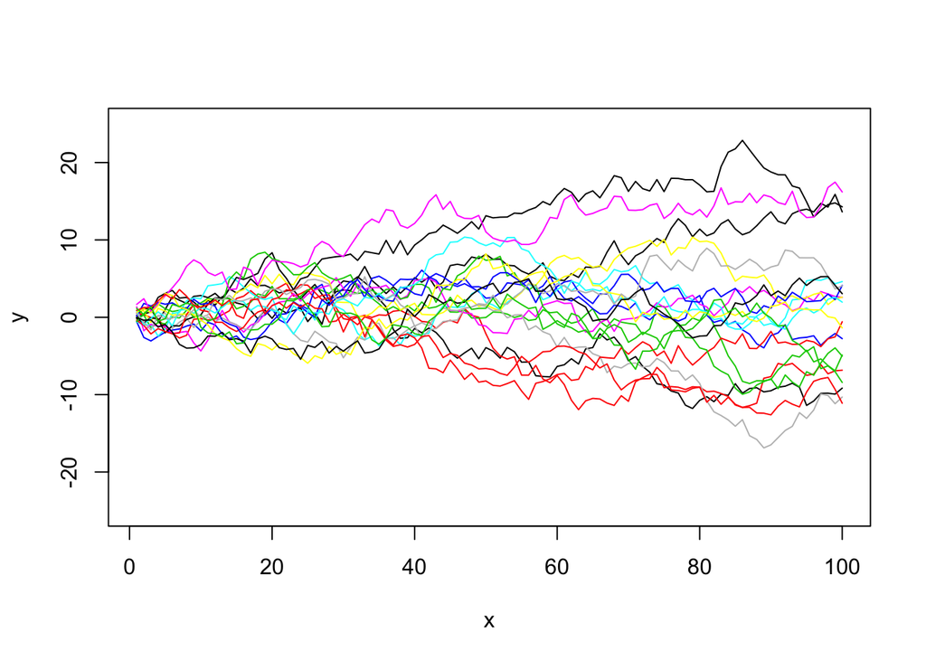

```r
# your code goes here
y <- rn100()
x <- seq_along(y)
plot(x, y, type = "l", ylim = c(-25,25))
for(i in 1:19) lines(x,rn100(),col = i)
```